# Module 1 Report

450598173

25 August 2018

The Australian road fatalities data is collected individually by the policemen/women in charge at the scene. It is then compiled and published by Australian Government’s Bureau of Infrastructure, Transport and Regional Economics [citeulike:14629294].

An overview of the data can be seen as below:

```r
glimpse(fdata)
```

```
## Observations: 49,154
## Variables: 14
## $ `Crash ID`                    <int> 20181001, 20181005, 20181009, 20...
## $ State                         <chr> "NSW", "NSW", "NSW", "NSW", "NSW...
## $ Month                         <chr> "June", "June", "June", "June", ...
## $ Year                          <int> 2018, 2018, 2018, 2018, 2018, 20...
## $ Dayweek                       <chr> "Tuesday", "Saturday", "Thursday...
## $ Time                          <time> 18:15:00, 15:00:00, 19:55:00, 2...
## $ Crash_Type                    <chr> "Pedestrian", "Multiple vehicle"...
## $ Bus_Involvement               <chr> "No", "No", "No", "No", "No", "N...
## $ Rigid_Truck_Involvement       <chr> "No", "No", "No", "No", "No", "N...
## $ Articulated_Truck_Involvement <chr> "No", "No", "No", "No", "No", "Y...
## $ Speed_Limit                   <int> 70, 60, 50, 100, 100, 100, 110, ...
## $ Road_User                     <chr> "Pedestrian", "Driver", "Pedestr...
## $ Gender                        <chr> "Male", "Female", "Male", "Male"...
## $ Age                           <int> 55, 22, 77, 47, 40, 50, 38, 55, ...
```

The data is reported in 14 categories: ‘Crash ID’ is the National crash-identifying number which is reported as a unique 8-digit integers. ‘State’ is Australian jurisdiction and is reported as a text with the abbreviation for each state/territory. ‘Month’ is the month of the crash and is reported as a text with one of the following: January, February, March, April, May, June, July, August, September, October, November and December. ‘Year’ is the year of the crash and is reported as an integer.

‘DayOfWeek’ is the day of week of crash and is recorded as a text with one of the following input: Monday, Tuesday, Wednesday, Thursday, Friday, Saturday and Sunday. ‘Time’ is the time of crash and is recorded in the hh:mm (hour:minutes) format. ‘Crash Type’ is a code summarising the type of crash with 3 values relating to the number of vehicles involved, and whether a pedestrian was killed and is recorded with either single, multiple or pedestrian.

‘Bus Involvement’ indicates the involvement of a bus in the crash, ‘Rigid Truck Involvement’ indicates the involvement of a rigid truck in the crash and ‘Articulated Truck Involvement’ indicates the involvement of an articulated truck in the crash are all recorded as with boolean values. ‘Speed Limit’ is the posted speed limited at the location of crash recorded as an integer value with ‘900’ as no speed limit posted at the location of crash.

‘Road User’ is the road user type that is killed in the crash with either one or a combination of the following inputs: driver, passenger, pedestrian, motorcycle rider, motorcycle pillion passenger and bicyclist. ‘Gender’ is the sex of killed person and is recorded as male or female. ‘Age’ is the age of killed person in years and is recorded as an integer value.

Missing values are recorded in the data with either ‘-9’ or ‘Unknown’. Missing values occured most likely due to human error such as missing archieve from past years, incomplete or missing paperwork of recent records and as a data scientist, one must be skeptical when presented with a set of data, missing values could be intentional to prove a point of the effect of a change in policy for political agenda [review2018hbr].

# Australian Fatal Crash

Trim data to hour:

```r
BITRE_ARDD_Fatal_Crashes_July2018 <- read.table("BITRE_ARDD_Fatal_Crashes_July2018.csv",sep=",",header=T)
```

```r
Hour_Edit <- BITRE_ARDD_Fatal_Crashes_July2018$Time
Hour_Edit1 <- strtrim(Hour_Edit, 2)
```

Bar Plot of Hour of Fatal Crash:

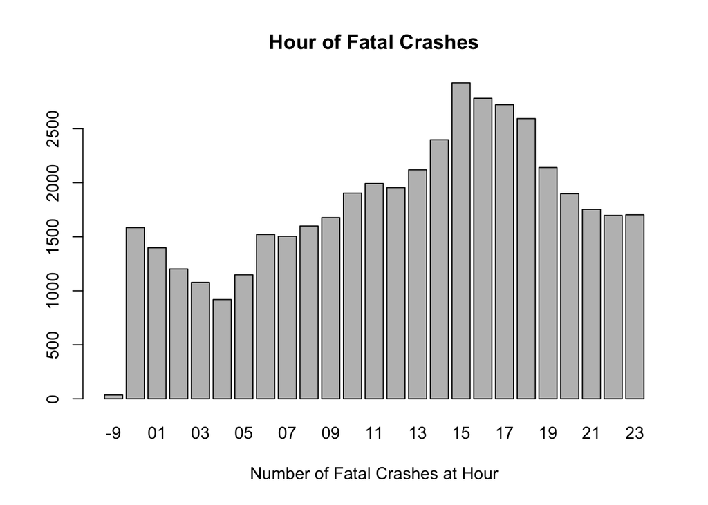

```r
counts <- table(Hour_Edit1)
barplot(counts, main="Hour of Fatal Crashes", xlab="Number of Fatal Crashes at Hour")
```

From the barplot above, it is evident that the most common hour of the fatal crash occured at the 15:00 hour mark.

Bar Plot of Day of Fatal Crash:

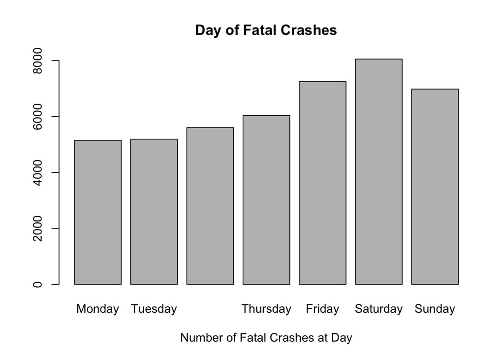

```r
BITRE_ARDD_Fatal_Crashes_July2018$Dayweek <- factor(BITRE_ARDD_Fatal_Crashes_July2018$Dayweek, levels = c("Monday", "Tuesday", "Wednesday", "Thursday", "Friday", "Saturday", "Sunday"))
counts1 <- table(BITRE_ARDD_Fatal_Crashes_July2018$Dayweek)
barplot(counts1, main="Day of Fatal Crashes", xlab="Number of Fatal Crashes at Day")
```

From the barplot above, it is evident that the most common day for a fatal crash occured on Saturday.

Bar Plot of Month of Fatal Xrash:

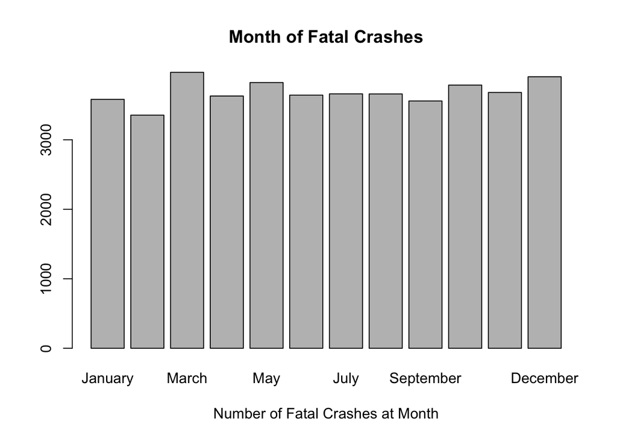

```r
BITRE_ARDD_Fatal_Crashes_July2018$Month <- factor(BITRE_ARDD_Fatal_Crashes_July2018$Month, levels = c("January", "February", "March", "April", "May", "June", "July", "August", "September", "October", "November", "December"))
counts2 <- table(BITRE_ARDD_Fatal_Crashes_July2018$Month)
barplot(counts2, main="Month of Fatal Crashes", xlab="Number of Fatal Crashes at Month")
```

Since, the barplot is very close for March and December, table for the number of fatal crashes for the month is needed:

```r
counts2
```

```
##
##   January  February     March     April       May      June      July
##      3582      3355      3971      3630      3824      3643      3661
##    August September   October  November  December
##      3660      3559      3787      3681      3907
```

From the table above, it is evident that the number of fatal crashes in March is the highest.

The plot above of the month of the fatal crash shows a similar number of crashes across the months. A null Hypothesis could be made that the crash occured for the month follow a uniform distribution. To check if this, we perform a hypothesis test.

```r
# Input observed counts
y_i = counts2

# Number of months
n = sum(y_i)

# Number of groups
k = length(y_i)

# Probability assuming a uniform distribution
p_i = c(1/k, 1/k, 1/k, 1/k, 1/k, 1/k, 1/k, 1/k, 1/k, 1/k, 1/k, 1/k)

# Expected counts
e_i = n*p_i
e_i
```

```
##  [1] 3688.333 3688.333 3688.333 3688.333 3688.333 3688.333 3688.333
##  [8] 3688.333 3688.333 3688.333 3688.333 3688.333
```

```r
# Test if e_i is greater than 5
e_i >= 5
```

```
##  [1] TRUE TRUE TRUE TRUE TRUE TRUE TRUE TRUE TRUE TRUE TRUE TRUE
```

```r
# Observed test statistic
t0 = sum((y_i - e_i)^2 /e_i)
round(t0,3)
```

```
## [1] 81.897
```

```r
# p-value
pval = 1 - pchisq(t0, k - 1)
round(pval,3)
```

```
## [1] 0
```

Since the p-value is < 0.05, there is strong evidence in the data against the null hypothesis. This suggest that there is at least one of the months where the probabilty of fatal crash is not equal to 1/12.

# ACT Fatal Crashes

Using the data viewer in Rstudio, the number of fatal crashes are 417 cases.

Summarising the Fatal Crashes in ACT:

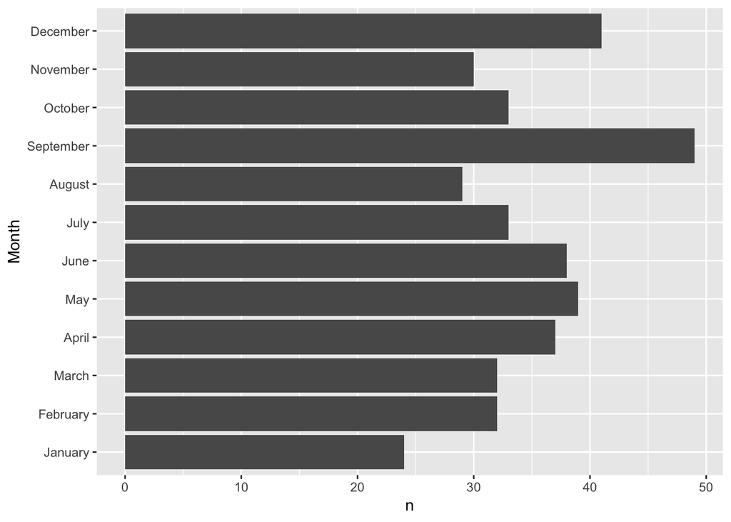

```r
counts = BITRE_ARDD_Fatal_Crashes_July2018 %>%
  dplyr::filter(State == "ACT") %>%
  dplyr::group_by(State, Year, Month) %>%
  dplyr::summarise(n = dplyr::n())
counts$Month = factor(counts$Month,
                        levels = c("January", "February", "March", "April", "May", "June", "July", "August", "September", "October", "November", "December"),
                        ordered = TRUE)

# and if we wanted to plot the counts
library(ggplot2)
ggplot(counts, aes(x = Month, y = n)) +
  geom_bar(stat = "identity") +
  coord_flip()
```

The plot above shows the frequency of fatal crashes for ACT in different months across 1989 and 2018. A null Hypothesis could be made that the crash occured for the month follow a Poisson distribution. To check if this, we perform a hypothesis test.

Summary for ACT fatal Crash:

```r
no_months = c(139, 120, 78, 31, 7, 4)
no_crashes = c(0, 1, 2, 3, 4, 5)
rbind(no_months, no_crashes)
```

```
##            [,1] [,2] [,3] [,4] [,5] [,6]
## no_months   139  120   78   31    7    4
## no_crashes    0    1    2    3    4    5
```

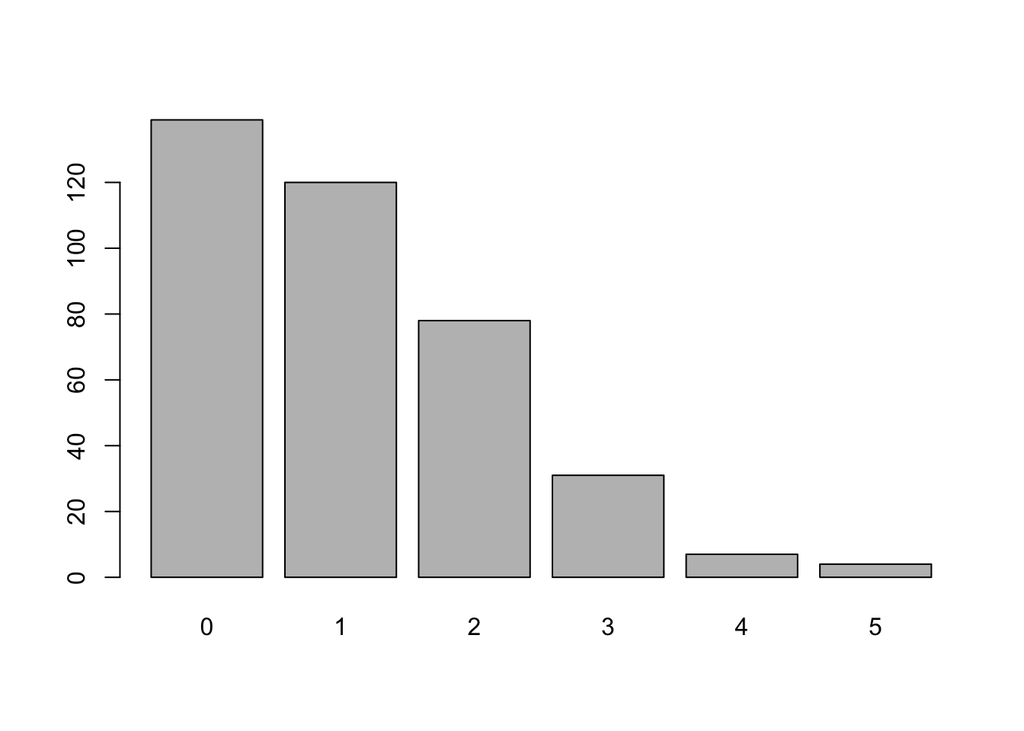

```r
barplot(no_months, names.arg = no_crashes)
```

The plot above shows the frequency of fatal crashes for ACT and the number of months across 1989 and 2018. A null Hypothesis could be made that the crash occured for the month follow a Poisson distribution. To check if this, we perform a hypothesis test.

```r
# number of months
n = sum(no_months)

# number of groups
k = length(no_months)

# estimate lambda parameter
lam = sum(no_months * no_crashes)/n
round(lam,2)
```

```
## [1] 1.1
```

```r
# obtain p_i from the Poisson pmf
p = dpois(no_crashes, lambda = lam)
p
```

```
## [1] 0.332783267 0.366149399 0.201430474 0.073875556 0.020320651 0.004471616
```

```r
# Re-define the 5th element
p[6] = 1 - sum(p[1:5])
p
```

```
## [1] 0.332783267 0.366149399 0.201430474 0.073875556 0.020320651 0.005440653
```

```r
# Calculate the expected frequencies
ey = n * p
ey
```

```
## [1] 126.124858 138.770622  76.342150  27.998836   7.701527   2.062008
```

```r
# Check if assumption e_i >= 5 if satisfied
ey > 5
```

```
## [1]  TRUE  TRUE  TRUE  TRUE  TRUE FALSE
```

```r
# Combine adjacent classes to satisfy assumptions
yr = c(no_months[1:4], no_months[5] + no_months[6])
yr
```

```
## [1] 139 120  78  31  11
```

```r
eyr = c(ey[1:4], ey[5] + ey[6])
eyr
```

```
## [1] 126.124858 138.770622  76.342150  27.998836   9.763534
```

```r
pr = c(p[1:4], p[5] + p[6])
pr
```

```
## [1] 0.33278327 0.36614940 0.20143047 0.07387556 0.02576130
```

```r
# number of combined classes
kr = length(yr)

# test statistic
t0 = sum((yr - eyr)^2 /eyr)
t0
```

```
## [1] 4.367591
```

```r
# p-value
pval = 1 - pchisq(t0, df = kr - 1 - 1)
round(pval,3)
```

```
## [1] 0.224
```

Since the p-value is > 0.05, we do not reject the null hypothesis. The data are consistent with a Poisson distribution.

# Truck Involvement and Crash Type

Investigating if there exist a relationship between articulated truck involvement and crash type.

```r
counts = fdata %>%
  dplyr::group_by(Crash_Type, Articulated_Truck_Involvement) %>%
  dplyr::summarise(n = dplyr::n())
```

```r
table = rbind(counts$Articulated_Truck_Involvement,counts$Crash_Type,counts$n)
```

```r
y = c(741, 19595, 3830, 17213, 437, 7338)
n = sum(y)
c = 3
r = 2
y.mat = matrix(y, nrow = r, ncol = c)
colnames(y.mat) = c("Single vehicle", "Multiple vehicle", "Pedestrian")
rownames(y.mat) = c("Yes", "No")
y.mat
```

```
##     Single vehicle Multiple vehicle Pedestrian
## Yes            741             3830        437
## No           19595            17213       7338
```

Visual representation of truck involvement and crash type:

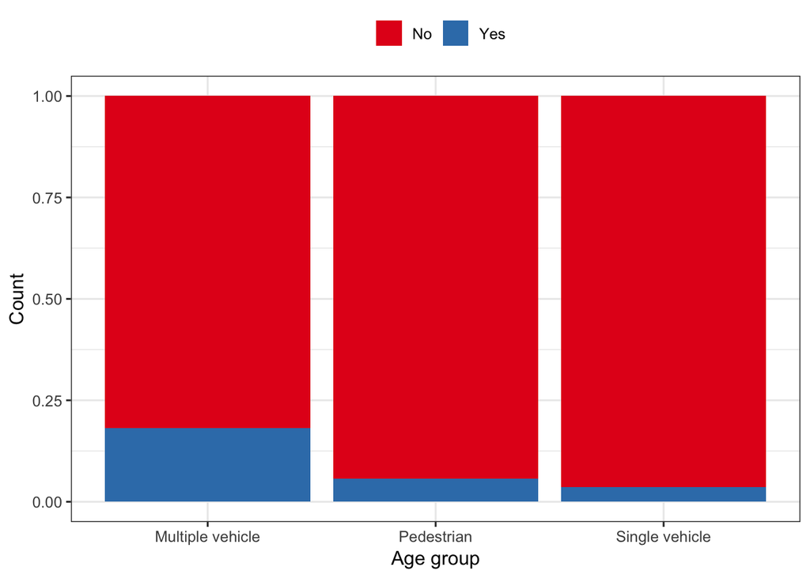

```r
y = matrix(c(741, 19595, 3830, 17213, 437, 7338), ncol = 3)
colnames(y) = c("Single vehicle", "Multiple vehicle", "Pedestrian")
rownames(y) = c("Yes", "No")
y1 = y %>% as.data.frame() %>%
  tibble::rownames_to_column(var = "viewing") %>%
  tidyr::gather(key = age, value = count, -viewing)
p_base = ggplot(y1, aes(x = age, y = count, fill = viewing)) +
  theme_bw(base_size = 12) +
  scale_fill_brewer(palette = "Set1") +
  labs(fill = "", x = "Age group") +
  theme(legend.position = "top")
p1 = p_base +
  geom_bar(stat = "identity", position = "fill") +
  labs(y = "Count")
p1
```

Chi-squared test is done:

```r
chisq.test(y.mat, correct = FALSE)
```

```
##
##  Pearson's Chi-squared test
##
## data:  y.mat
## X-squared = 2605.6, df = 2, p-value < 2.2e-16
```

```r
# Row sums of y.mat
yr = apply(y.mat, 1, sum)
yr
```

```
##   Yes    No
##  5008 44146
```

```r
# Column sums of y.mat
yc = apply(y.mat, 2, sum)
yc
```

```
##   Single vehicle Multiple vehicle       Pedestrian
##            20336            21043             7775
```

```r
yr.mat = matrix(yr, r, c, byrow = FALSE)
yc.mat = matrix(yc, r, c, byrow = TRUE)

# Matrix multiplication: ey.mat = yr * t(yc) /n
ey.mat = yr.mat * yc.mat / sum(y.mat)
ey.mat
```

```
##          [,1]      [,2]      [,3]
## [1,]  2071.91  2143.942  792.1471
## [2,] 18264.09 18899.058 6982.8529
```

```r
# Check if all e_ij is greater than 5
all(ey.mat >= 5)
```

```
## [1] TRUE
```

```r
# Test statistic
t0 = sum((y.mat - ey.mat)^2 / ey.mat)
round(t0,3)
```

```
## [1] 2605.578
```

```r
# p-value
pval = pchisq(t0, (r - 1) * (c - 1), lower.tail = FALSE)
pval
```

```
## [1] 0
```

Monte Carlo p-value:

```r
# Calculate row and column totals:
row_totals = rowSums(y.mat)
row_totals
```

```
##   Yes    No
##  5008 44146
```

```r
col_totals = colSums(y.mat)
col_totals
```

```
##   Single vehicle Multiple vehicle       Pedestrian
##            20336            21043             7775
```

Randomly generate a contingency table with same row and column totals:

```r
set.seed(2018)
rnd = r2dtable(n = 1, r = row_totals, c = col_totals)
chisq.test(rnd[[1]])$statistic
```

```
## X-squared
## 0.5600591
```

Monte-Carlo p-value obtained by generating 10,000 contingency tables, computing chi-squared test statistic for each table.

```r
B = 10000
stat = numeric(length = B)
tables = r2dtable(n = B, r = row_totals, c = col_totals)
for (i in 1:B) {
  stat[i] = suppressWarnings(chisq.test(tables[[i]], )$statistic)
}
stat = sapply(tables, function(x) suppressWarnings(chisq.test(x)$statistic))
mc_pval = mean(stat > t0)
mc_pval
```

```
## [1] 0
```

Distribution of test statistics:

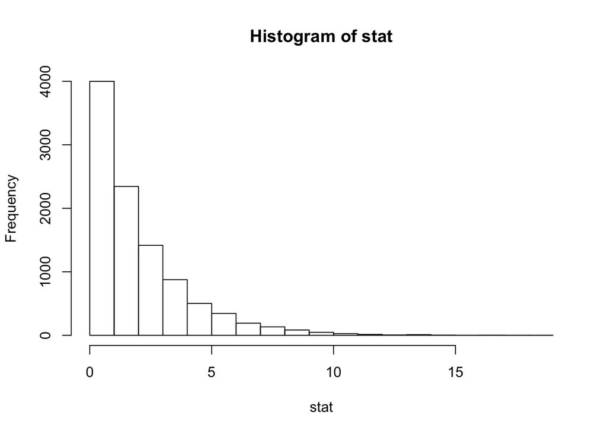

```r
hist(stat)
```

# Speed Limit and Fatalities

A journal article “Relationship of traffic fatality rates to maximum state speed limits” by Charles M. Farmer states that in the U.S. during 1993-2013, an increase in speed limit resulted in an increase of fatalities [doi:10.1080/15389588.2016.1213821]. This report aims to investigate the similarity between Australia and the US’ correlation for speed limit and fatality cases.

Summarising the fatal crashes into speed limit

```r
counts5 = fdata %>%
  dplyr::group_by(Speed_Limit) %>%
  dplyr::summarise(n = dplyr::n())
counts5
```

```
## # A tibble: 20 x 2
##    Speed_Limit     n
##          <int> <int>
##  1          -9   737
##  2           5     1
##  3           8     1
##  4          10    19
##  5          20    24
##  6          25     6
##  7          30    12
##  8          40   292
##  9          45     1
## 10          50  2478
## 11          60 13082
## 12          70  2342
## 13          75   254
## 14          80  5579
## 15          90  1060
## 16         100 17042
## 17         110  5514
## 18         130    93
## 19         888     3
## 20         900   614
```

```r
# Delete missing data
counts5a <- counts5[-c(1),]
```

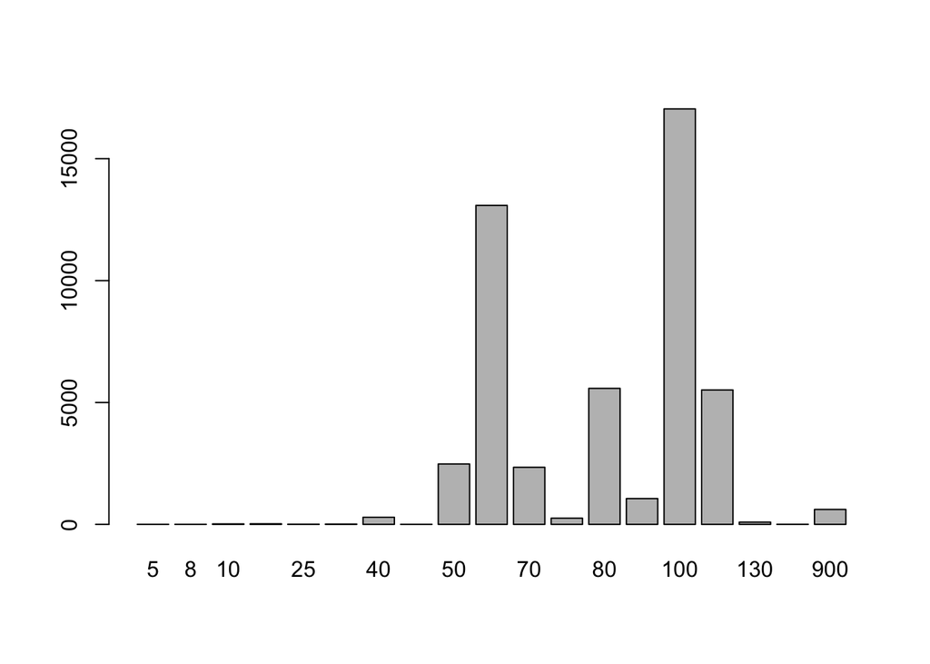

```r
barplot(counts5a$n, names.arg = counts5a$Speed_Limit)
```

The plot above shows the frequency of fatal crashes for Australia and the speed limits across 1989 and 2018. A null Hypothesis could be made that the crash occured for the speed limit follow a Poisson distribution. To check if this, we perform a hypothesis test.

```r
# number of speed limits
n = sum(counts5a$n)

# number of groups
k = length(counts5a$n)

# estimate lambda parameter
lam = sum(counts5a$n * counts5a$Speed_Limit)/n
round(lam,2)
```

```
## [1] 93.45
```

```r
# obtain p_i from the Poisson pmf
p = dpois(counts5a$Speed_Limit, lambda = lam)
p
```

```
##  [1] 1.545689e-33 3.754163e-30 3.642706e-28 2.759498e-20 3.084556e-17
##  [6] 1.285470e-14 2.122485e-10 1.031719e-08 2.891893e-07 5.368460e-05
## [11] 1.894031e-03 6.517245e-03 1.610022e-02 3.939047e-02 3.184864e-02
## [16] 9.504829e-03 6.021487e-05 0.000000e+00 0.000000e+00
```

```r
# Re-define the 18th element
p[19] = 1 - sum(p[1:18])
p
```

```
##  [1] 1.545689e-33 3.754163e-30 3.642706e-28 2.759498e-20 3.084556e-17
##  [6] 1.285470e-14 2.122485e-10 1.031719e-08 2.891893e-07 5.368460e-05
## [11] 1.894031e-03 6.517245e-03 1.610022e-02 3.939047e-02 3.184864e-02
## [16] 9.504829e-03 6.021487e-05 0.000000e+00 8.946304e-01
```

```r
# Calculate the expected frequencies
ey = n * p
ey
```

```
##  [1] 7.483764e-29 1.817653e-25 1.763689e-23 1.336066e-15 1.493450e-12
##  [6] 6.223862e-10 1.027643e-05 4.995275e-04 1.400168e-02 2.599247e+00
## [11] 9.170328e+01 3.155455e+02 7.795243e+02 1.907169e+03 1.542015e+03
## [16] 4.601953e+02 2.915423e+00 0.000000e+00 4.331532e+04
```

```r
# Check if assumption e_i >= 5 if satisfied
ey > 5
```

```
##  [1] FALSE FALSE FALSE FALSE FALSE FALSE FALSE FALSE FALSE FALSE  TRUE
## [12]  TRUE  TRUE  TRUE  TRUE  TRUE FALSE FALSE  TRUE
```

```r
# Combine adjacent classes to satisfy assumptions
yr = c(counts5a$n[1] + counts5a$n[2] + counts5a$n[3] + counts5a$n[4] + counts5a$n[5] + counts5a$n[6] + counts5a$n[7] + counts5a$n[8] + counts5a$n[9] + counts5a$n[10], counts5a$n[11:16], counts5a$n[17] + counts5a$n[18] + counts5a$n[19])
yr
```

```
## [1] 15916  2342   254  5579  1060 17042  5514   710
```

```r
eyr = c(ey[1] + ey[2] + ey[3] + ey[4] + ey[5] + ey[6] + ey[7] + ey[8] + ey[9] + ey[10], ey[11:16], ey[17] + ey[18] + ey[19])
eyr
```

```
## [1]     2.613759    91.703285   315.545464   779.524343  1907.168615
## [6]  1542.015373   460.195312 43318.233849
```

```r
pr = c(p[1] + p[2] + p[3] + p[4] + p[5] + p[6] + p[7] + p[8] + p[9] + p[10], p[11:16], p[17] + p[18] + p[19])
pr
```

```
## [1] 5.398432e-05 1.894031e-03 6.517245e-03 1.610022e-02 3.939047e-02
## [6] 3.184864e-02 9.504829e-03 8.946906e-01
```

```r
# number of combined classes
kr = length(yr)

# test statistic
t0 = sum((yr - eyr)^2 /eyr)
t0
```

```
## [1] 97224075
```

```r
# p-value
pval = 1 - pchisq(t0, df = kr - 1 - 1)
pval
```

```
## [1] 0
```

Since the p-value is < 0.05, we reject the null hypothesis. The data are not consistent with a Poisson distribution.

# Data Limitations

As with many dataset, this dataset by BITRE is not exempted from flaws and limitations. Such as the existence of missing values raises doubt for the autenticity of the data and we do not have the total number of cars on the road. This is crucial as even though the test may suggest an increase in speed limit may increase the fatalies however, the fatalities rate may actually decrease.

Let’s say in 1989, there is 1 case of fatality for 100 cars and in 1990, there is a new policy of introducing a speed limit and has 2 cases of fatalities. Without any additional information, one may confidently claim that the rate of fatalities increases by 100% and that the introduction of speed limit is bad but an introduction of a new information, say that in 1990, the rate is actually 2 cases of fatalities for 500 cars. With this information, the probabilty of a fatal case actually decreases from 0.01 to 0.004 and the policy which was previously deemed terribly appear to be a success.

# References

```r
citation("ggplot2")
```

```
##
##
##   H. Wickham. ggplot2: Elegant Graphics for Data Analysis.
##   Springer-Verlag New York, 2016.
##
## A BibTeX entry for LaTeX users is
##
##   @Book{,
##     author = {Hadley Wickham},
##     title = {ggplot2: Elegant Graphics for Data Analysis},
##     publisher = {Springer-Verlag New York},
##     year = {2016},
##     isbn = {978-3-319-24277-4},
##     url = {http://ggplot2.org},
##   }
```

```r
citation("tidyverse")
```

```
##
##
##   Hadley Wickham (2017). tidyverse: Easily Install and Load the
##   'Tidyverse'. R package version 1.2.1.
##   https://CRAN.R-project.org/package=tidyverse
##
## A BibTeX entry for LaTeX users is
##
##   @Manual{,
##     title = {tidyverse: Easily Install and Load the 'Tidyverse'},
##     author = {Hadley Wickham},
##     year = {2017},
##     note = {R package version 1.2.1},
##     url = {https://CRAN.R-project.org/package=tidyverse},
##   }
```